# Introduction_to_settleR

# Background and Motivation

I had a need to convey combinations of sets and found the the usual method to do this, venn-diagrams or Euler plots too limiting. My research invovles identifying differentially expressed genes which involved looking large numbers of datasets which could be grouped any number of ways. I found [UpSet plots](https://github.com/hms-dbmi/UpSetR/) to offer a succint way to visualize these comparisons which is relatively intuitive to my audience. There is already an [UpSet package](https://cran.rstudio.com/web/packages/UpSetR/), however, I found it was not amenable to customization. In my experience, it is very difficult to write re-usable, modular code creating plots for anything besides one-off functions that will be used once, or at most a single context.

# settleR: A simple and customizable package for creating UpSet plots

I created the settleR package to to address the percieved challenges primarily for my own needs, but I hope that others may find it useful too. The goal of settleR is to:

1. Create a simple/modular framework for UpSet-like figures
2. Make creating figures as painless as possible
3. Allow for arbitrary customization

```r
library(settleR)
library(grid)
```

# Creating a basic plot

```r
# Loads an example setlist
gene_setlist <-
  system.file('extdata','ex_gene_setlist.rds', package = 'settleR') %>%
  readRDS(.)

# Creating the SettleR object
setobj <- SettleR(gene_setlist)
```

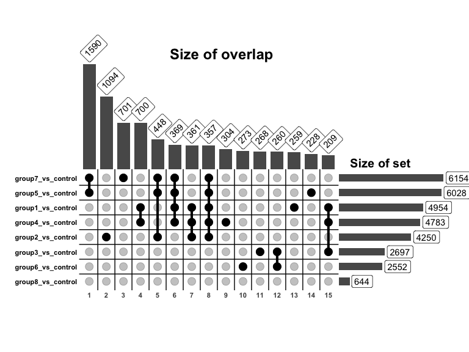

```r
# Plotting to the device
settleR_plot(setobj)
```

## Recommend way of saving a plot

You’re free to save the plot anyway you like, which is likely different depending on your workflow. I personally end up spending a great deal of time perfecting the dimensions of my plots. The settleR plots are no different. However, I’ve managed to automate this through trial & error for these plots. Once the plot is to your liking, I recommend using the `settleR_save` to save the plot.

```r
# Recommended way to save the plot
settleR_save(setobj, 'example_settleR_plot.pdf')
```

# settleR plot customizations

## Adding color to the groups

You can create a `SettleR` plot with colour coded names on the left side of the grid plot. To do this, pass a named vector of colours which match the names of the groups. This can be done by either passing the `colMap` parameter while the object is initilized, or after.

```r
col_map <-
  system.file('extdata','ex_col_map.rds', package = 'settleR') %>%
  readRDS(.)


# Creating the SettleR object w/ colors
setobj <- SettleR(gene_setlist, colMap = col_map)
# Changning the colors on a created object
colMap(setobj) <- col_map
```

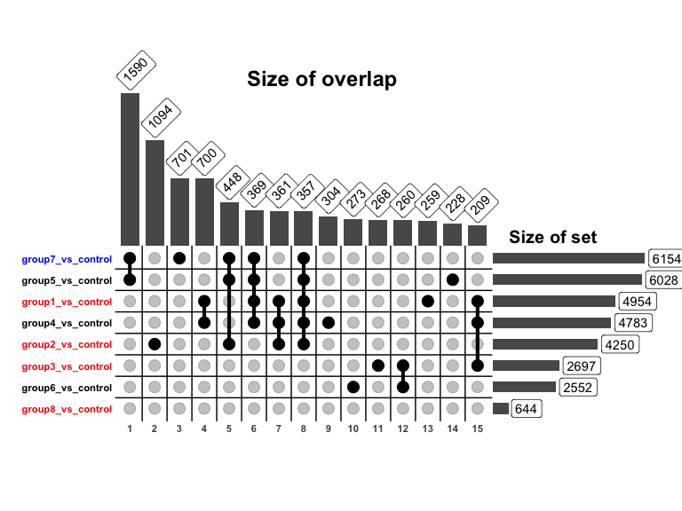

```r
# Plotting to the device
settleR_plot(setobj)
```

## Specifying the order of the groups

This is an example of how you can control the order of the groups in the plot.

```r
set_levels <-
  system.file('extdata','ex_set_levels.rds', package = 'settleR') %>%
  readRDS(.)

# Creating the SettleR object ordered groups
setobj <- SettleR(gene_setlist, setLevels = set_levels)
# Changning group order on a created object
setLevels(setobj) <- set_levels
```

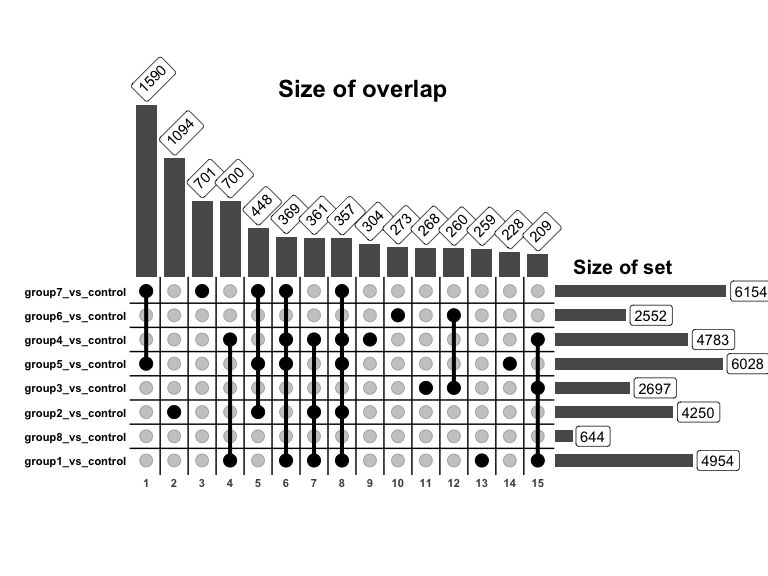

```r
# Plotting to the device
settleR_plot(setobj)
```

## Place the singleton intersects first

It can be helpful to see which items are exclusive to a given group. I’ve dubbed these singletons, and can be placed in the front of the plot.

```r
setobj <- SettleR(gene_setlist, setLevels = set_levels)
setobj <- reorder_by_singletons(setobj)
```

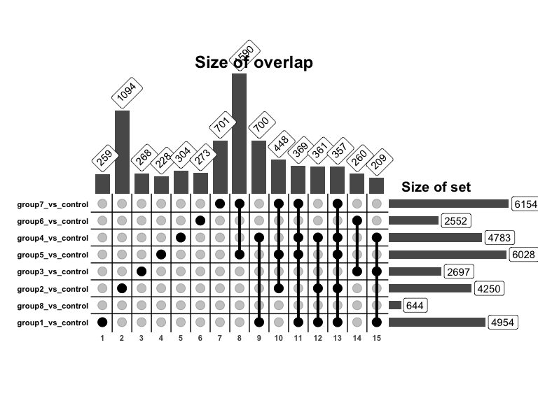

```r
settleR_plot(setobj)
```

# Advanced customizations

## Modifications of the underlying ggplots

This is where `settleR` really shines. As described in the intro, I made this package with modularity in mind. Below is an example of how you can modify one of the underlying `ggplot`s, then put this back into the `SettleR` object and then make a new `settleRPlot`. A simple example for illustrative purposes is shown below.

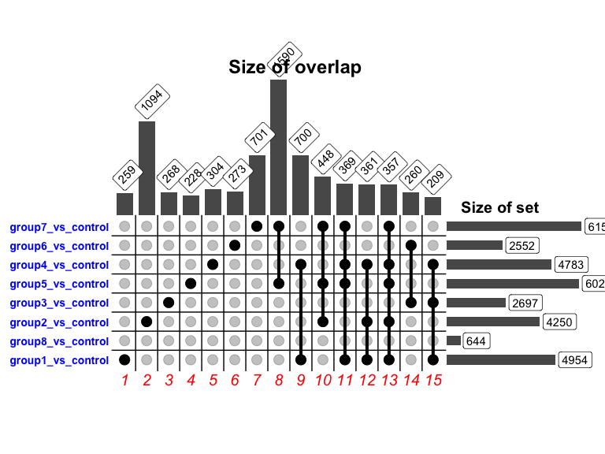

```r
# Getting the grid plot
tmp_plt <- gridPlot(setobj)
# Making modifications to the text using "theme" from ggplot2
tmp_plt <- tmp_plt +
  theme(axis.text.y = element_text(colour = 'blue', face="bold", size = rel(.875)),
        axis.text.x = element_text(colour='red', face='italic', size = rel(1.25)))
# Updating the SettleR object with the modified plot
gridPlot(setobj) <- tmp_plt
settleR_plot(setobj)
```

## Adding boxes around specific groups

Here’s a more complicated example. I had a need of highlighting specific intersects on the plot. The solution I cam up with is to draw a red box around the intersect(s) of interest. The function to include the dimensions is included in `settleR`.

```r
# Extracting the grid plot and intersect levels
tmp_plt <-  gridPlot(setobj)
intersect_lvls <- intersectLevels(setobj)

# Getting the dimensions for the box
bound_boxes <- intersect_lvls[c(10:13)] %>%
  box_intercepts_dims(tmp_plt, .)

# Using geom_rect to draw red boxes
tmp_plt <- tmp_plt +
  geom_rect(data=bound_boxes,aes(xmin=xmin, xmax=xmax, ymin=ymin,ymax=ymax),
            inherit.aes = FALSE,
            color='red',
            fill=NA,
            size=.75
  )
# Replacing the modified gridPlot
gridPlot(setobj) <- tmp_plt
settleR_plot(setobj)
```

[output not shown]

# Creating Venn Diagram

## Creating 3-venn diagram plots

This is the code which I’ve used to make an visual represention of the overlap. It’s modified from [StackExchange answer]{https://stackoverflow.com/questions/43963293/how-to-define-color-of-intersection-in-a-venn-diagram}

```r
library(VennDiagram)
library(sp)
library(lefutils)
library(rgeos)


vp <- venn.diagram(d, alpha = 1, filename = NULL,
                   category.names=c("A", "B", "C"), scaled=FALSE, euler.d=FALSE)

ix <- sapply(vp, function(x) grepl("text", x$name, fixed = TRUE))
labs <- do.call(rbind.data.frame, lapply(vp[ix], `[`, c("x", "y", "label")))

# Tries to convert str to numbers. Those which
# Are NA are letters
lab_positions <- labs[is.na(as.numeric(labs$label)),]
lab_positions$label <- c("1", "2", "3")


circles <- vp[4:6]
venn_polygons <- lapply(seq_along(circles), function(i){
  cur_circ <- circles[[i]]
  x <- cur_circ[['x']]
  y <- cur_circ[['y']]
  # I have no idea what the below line does.
  p <- SpatialPolygons(list(Polygons(list(Polygon(cbind(x, y))), ID = i)))
}) %>% setNames(., c("1", "2", "3"))

abc_overlap <- reduce(venn_polygons, gIntersection)
ab_overlap <- gIntersection(venn_polygons[[1]], venn_polygons[[2]]) %>% gDifference(., venn_polygons[[3]])
a_overlap <- gDifference(venn_polygons[[1]], venn_polygons[[2]]) %>% gDifference(., venn_polygons[[3]])



create_custom_annotation <- function(text, x=.25, y=1.05, size=18){
  text_annot <-
    grobTree(textGrob(text,
                      x=x,
                      y=y,
                      hjust=0,
                      gp=gpar(col="black",
                              fontsize=size,
                              fontface="bold")))

  return(text_annot)
}
create_gg_venn <- function(venn_polygons, ip, lab_positions){

  intersect_area <-
    ip@polygons[[1]]@Polygons[[1]]@coords %>%
    as_tibble(.) %>%
    setNames(., c('x', 'y'))

  circles_area <-
    lapply(venn_polygons, function(x){
      x@polygons[[1]]@Polygons[[1]]@coords %>%
        as_tibble(.) %>%
        setNames(., c('x', 'y'))
    }) %>%
    setNames(., c("1", "2", "3"))

  plot_data <- rbind_named_df_list(circles_area, 'group')


  plt <-  ggplot() +
    geom_path(data=plot_data, aes(x=x, y=y, group=group)) +
    geom_polygon(data=intersect_area, aes(x=x, y=y)) +
    geom_text(data=lab_positions,
              aes(x=x, y=y, label=label),
              size=8,
              fontface='bold',
              nudge_y = -.02) +
    theme_void()


  # plt <- plt +theme(plot.margin=margin(0, 0, 0, 0), aspect.ratio = 1)
  plt <- plt +theme(plot.margin=margin(0, 0, 0, 0))




  return(plt)

}


venn_plots <-
  list(a_overlap, ab_overlap, abc_overlap) %>%
  lapply(., function(x){
    create_gg_venn(venn_polygons, x, lab_positions)
  })


annot_text_list <- c('A only', 'A & B overlap', 'A, B, & C overlap')
```

This has turned out to be much more involved than I had initially expected. I should add this functionality to settleR.

## Creating a Grid plot matching the Venn diagrams

```r
## Making the grids
intersect_id <- factor(rep(paste0("intersect_", 1:3), 3))
set_names <- factor(rep(LETTERS[1:3], 3))
observed <- as.logical(c(1,1,1, 1,1,0, 1,0,0))



grid_data <-
  data.frame(intersect_id,set_names,observed ) %>%
  arrange(set_names, intersect_id)
grid_data$intersect_id <- factor(intersect_id)



grid_plts <-
    rev(split(grid_data,grid_data$intersect_id)) %>%
    lapply(., function(x){
      tmp_plt <- grid_dot_plot(x, dot_size = 10)
      tmp_plt <- tmp_plt +
        theme(plot.margin = unit(c(0, 0, 0, 0), "pt"))

      tmp_plt$layers[[4]] <- NULL
      # tmp_plt <- get_panel(tmp_plt)
      return(tmp_plt)

    })




adjust <- .05
line_coords <- c(.5 - adjust, 1.5 + adjust)
grid_plts$intersect_2 <- grid_plts$intersect_2 + geom_vline(xintercept = line_coords)

grid_plts <- lapply(grid_plts, get_panel)

comb_plts <- lapply(seq_along(grid_plts), function(i){
  pl <- list(as_grob(venn_plots[[i]]), grid_plts[[i]])
  tmp_plt <-
    plot_grid(plotlist = pl,
              align = 'v',
              axis ='tb',
              ncol = 1,
              rel_heights = c(6, 4), rel_widths = c(1,1))
})



ggsave2('grid_venn_diagram.pdf', plot = plot_grid(plotlist = comb_plts, nrow = 1, labels = "AUTO", label_y = .5, label_x=0, label_size=24 ), height = 4.5, width = 9)
```